# GW_Yerik_Analysis

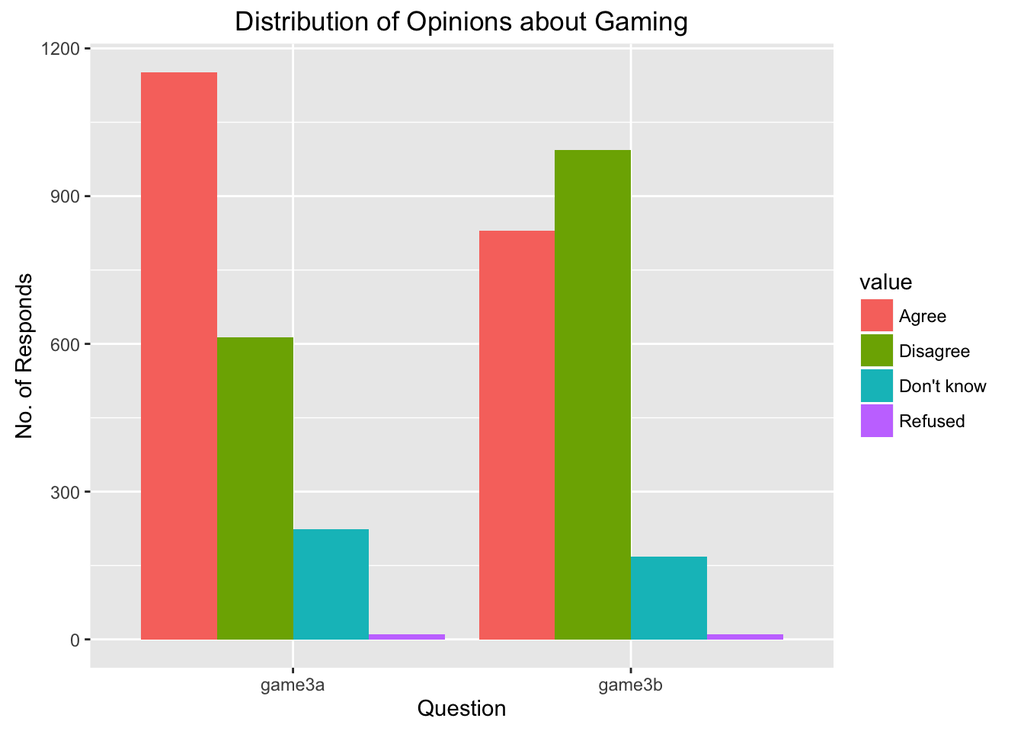

```r
ggplot(data = mgame3, aes(x=variable,fill=value))+geom_bar(stat = "count",position="dodge")+labs(x="Question",y="No. of Responds",title="Distribution of Opinions about Gaming")
```

game4: “Some people use the term “gamer” to describe themselves as a fan of gaming or a frequent game player. Do you think the term “gamer” describes you well, or not?”

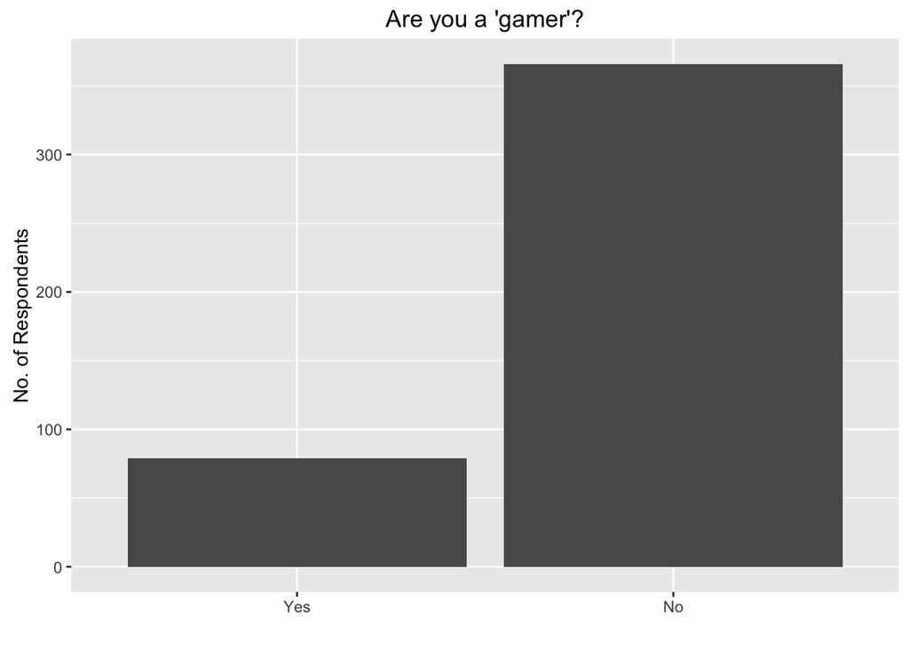

```r
game4 <- gjb[gjb[c("game1")]==1,]
game4 <- game4[game4["game4"]==c(1,2),]
ggplot(data = game4, aes(x=factor(game4,levels=c(1,2),labels=c("Yes","No"))))+geom_bar(position="dodge",stat="count")+labs(x="", y="No. of Respondents", title="Are you a 'gamer'?")
```

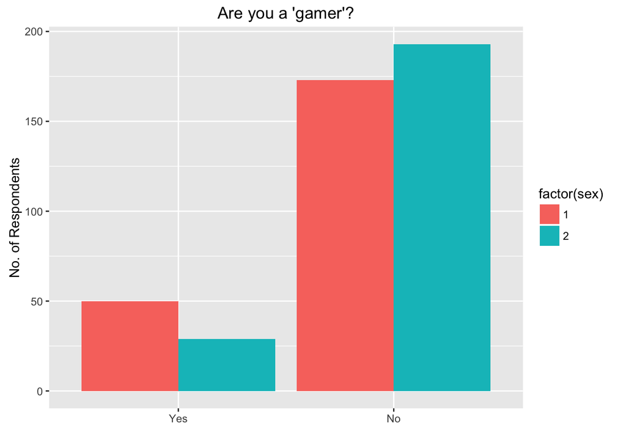

```r
ggplot(data = game4, aes(x=factor(game4,levels=c(1,2),labels=c("Yes","No")),fill=factor(sex)))+geom_bar(position="dodge",stat="count")+labs(x="", y="No. of Respondents", title="Are you a 'gamer'?")
```

### Q4: The relationship between gaming and dating

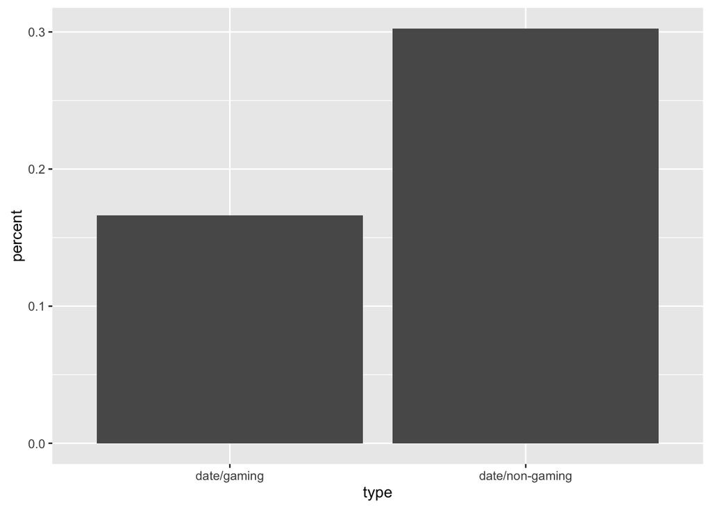

```r
#gaming/non-gaming people who did or didn't have online dating
a <- nrow(game4[game4[,"date1a"]==1,])/nrow(game4) #dating Yes / gaming
b <- nrow(game4[game4[,"date1a"]==2,])/nrow(game4) #dating No / gaming
game4_n <- gjb[gjb[c("game1")]==2,]
c <- nrow(game4_n[game4_n[,"date1a"]==1,])/nrow(game4_n) #dating Yes / no-gaming
d <- nrow(game4_n[game4_n[,"date1a"]==2,])/nrow(game4_n) #dating No / no-gaming
gd <- data.frame(type=c("date/gaming","date/non-gaming"),percent=c(a,c))
ggplot(data=gd, aes(x=type,y=percent))+geom_bar(stat="unique")
```

```r
mat <- matrix(c(a,b,c,d),byrow=F,nrow=2)
colnames(mat) <- c("Gaming","Non-Gaming")
rownames(mat) <- c("Dating","Non-Dating")
#chisq.test(mat)
gd_test <- gjb[gjb["game1"] == c(1,2) & gjb["date1a"] ==c(2),c("date1a","game1")]
gd_test <- na.omit(gd_test)
#summary(gd_test)
gd_test$game1 <- factor(gd_test$game1,level=c(1,2),labels=c("Game","Non-Gaming"))
gd_test$date1a <- factor(gd_test$date1a,level=c(2),labels=c("Non-Dating"))
chisq.test(table(gd_test[,"date1a"],gd_test[,"game1"]))
```

```
##
##  Chi-squared test for given probabilities
##
## data:  table(gd_test[, "date1a"], gd_test[, "game1"])
## X-squared = 0.13089, df = 1, p-value = 0.7175
```

```r
#not sure this chisq.test was used correctly
```

#### Conclusion:

- 1 Non-gaming population has a higer percentage of online dating.
- 2 The percentage of people who had no online dating is similar among gaming and non-gaming population

### Q5: The Impact of Demographic Data on Online Dating

```r
#Gender, Race, Highest Education, Marital status, Age, Income; impact on dating
date_logit <- gjb[gjb[c("eminuse")]==1 | gjb[c("intmob")] ==1,c("date1a","sex","race","educ2","marital","age","inc")]
date_logit <- date_logit[date_logit["date1a"] == c(1,2),]
date_logit$date1a[which(date_logit["date1a"]==2)] <- 0
date_logit$date1a[which(date_logit["sex"]==2)] <- 0
date_logit$race[which(date_logit["race"]>1)] <- 0
for (i in 1:nrow(date_logit)) {
  if (date_logit[i,"age"] <= 35) date_logit[i,"age"] <- 1
  if (date_logit[i,"age"] > 35 & date_logit[i,"age"] <= 50) date_logit[i,"age"] <- 2
  if (date_logit[i,"age"] > 50) date_logit[i,"age"] <- 3
  }
summary(date_logit)
```

```
##      date1a             sex            race            educ2
##  Min.   :0.00000   Min.   :1.00   Min.   :0.0000   Min.   : 1.000
##  1st Qu.:0.00000   1st Qu.:1.00   1st Qu.:0.0000   1st Qu.: 3.000
##  Median :0.00000   Median :1.00   Median :1.0000   Median : 5.000
##  Mean   :0.06897   Mean   :1.49   Mean   :0.7444   Mean   : 6.054
##  3rd Qu.:0.00000   3rd Qu.:2.00   3rd Qu.:1.0000   3rd Qu.: 6.000
##  Max.   :1.00000   Max.   :2.00   Max.   :1.0000   Max.   :99.000
##     marital           age             inc
##  Min.   :1.000   Min.   :1.000   Min.   : 1.00
##  1st Qu.:1.000   1st Qu.:1.000   1st Qu.: 4.00
##  Median :1.000   Median :3.000   Median : 6.00
##  Mean   :2.636   Mean   :2.226   Mean   :18.73
##  3rd Qu.:5.000   3rd Qu.:3.000   3rd Qu.: 8.00
##  Max.   :9.000   Max.   :3.000   Max.   :99.00
```

```r
mylogit1 <- glm(date1a~sex+race+educ2+marital+age+inc,data=date_logit,family = "binomial")
summary(mylogit1)
```

```
##
## Call:
## glm(formula = date1a ~ sex + race + educ2 + marital + age + inc,
##     family = "binomial", data = date_logit)
##
## Deviance Residuals:
##     Min       1Q   Median       3Q      Max
## -1.3118  -0.4063   0.0000   0.0000   2.4608
##
## Coefficients:
##              Estimate Std. Error z value Pr(>|z|)
## (Intercept)  25.40030  794.45383   0.032 0.974494
## sex         -28.08139  794.45363  -0.035 0.971803
## race          0.99744    0.39700   2.512 0.011989 *
## educ2         0.14730    0.06774   2.175 0.029667 *
## marital       0.25845    0.07618   3.393 0.000692 ***
## age          -0.20657    0.19266  -1.072 0.283637
## inc          -0.17610    0.06557  -2.686 0.007242 **
## ---
## Signif. codes:  0 '***' 0.001 '**' 0.01 '*' 0.05 '.' 0.1 ' ' 1
##
## (Dispersion parameter for binomial family taken to be 1)
##
##     Null deviance: 422.11  on 840  degrees of freedom
## Residual deviance: 283.96  on 834  degrees of freedom
## AIC: 297.96
##
## Number of Fisher Scoring iterations: 20
```

```r
mylogit2 <- glm(date1a~sex+race+educ2+marital+inc,data=date_logit,family = "binomial")
summary(mylogit2)
```

```
##
## Call:
## glm(formula = date1a ~ sex + race + educ2 + marital + inc, family = "binomial",
##     data = date_logit)
##
## Deviance Residuals:
##     Min       1Q   Median       3Q      Max
## -1.2554  -0.4077   0.0000   0.0000   2.5562
##
## Coefficients:
##              Estimate Std. Error z value Pr(>|z|)
## (Intercept)  24.55101  807.64609   0.030  0.97575
## sex         -27.70811  807.64616  -0.034  0.97263
## race          0.95499    0.39293   2.430  0.01508 *
## educ2         0.14021    0.06772   2.070  0.03841 *
## marital       0.29671    0.06835   4.341 1.42e-05 ***
## inc          -0.17274    0.06570  -2.629  0.00855 **
## ---
## Signif. codes:  0 '***' 0.001 '**' 0.01 '*' 0.05 '.' 0.1 ' ' 1
##
## (Dispersion parameter for binomial family taken to be 1)
##
##     Null deviance: 422.11  on 840  degrees of freedom
## Residual deviance: 285.10  on 835  degrees of freedom
## AIC: 297.1
##
## Number of Fisher Scoring iterations: 20
```

#### Conclusion:

- 1 Gender has little effect on determining whether a person had online dating or not.
- 2 Race, education, maritial status and income all have significant statistical effects on determining whether a person had dating or not; marital status is the most significant factor. (but I’m confused in interpreting the model, will discuss you later)